# TiDEomics Application: Macrophage response to six immune stimuli

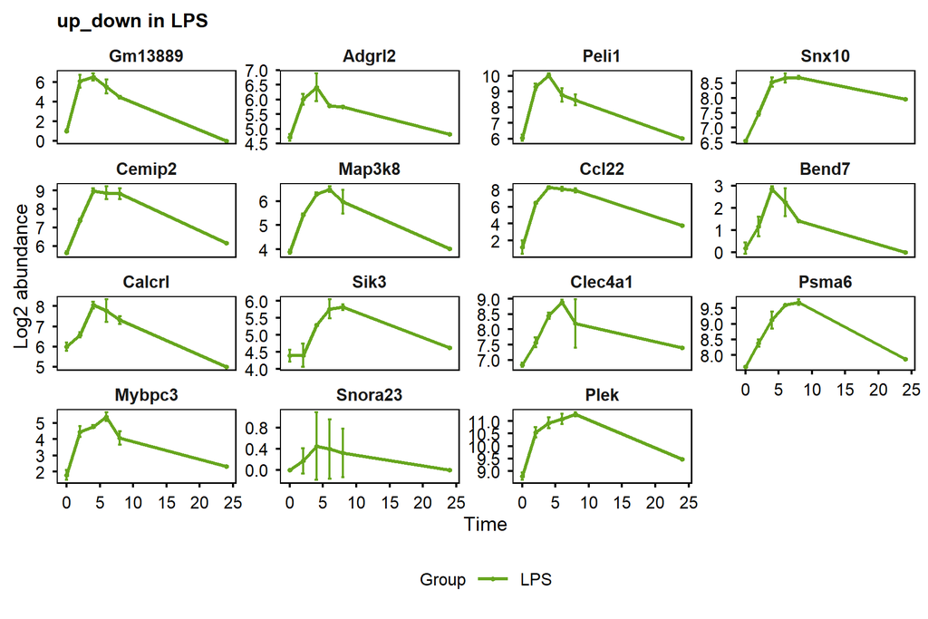

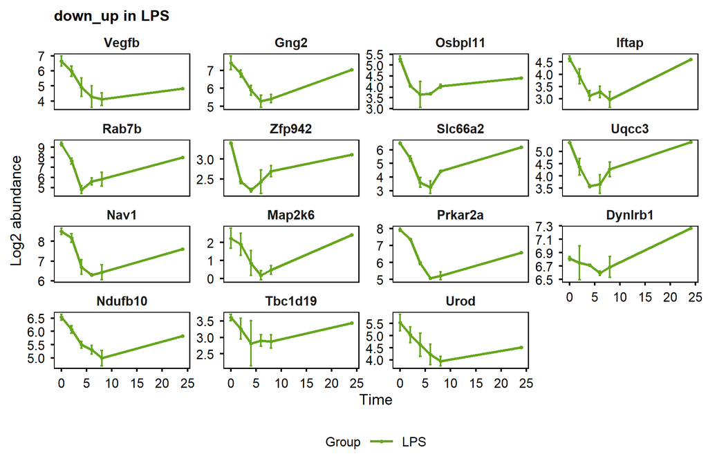

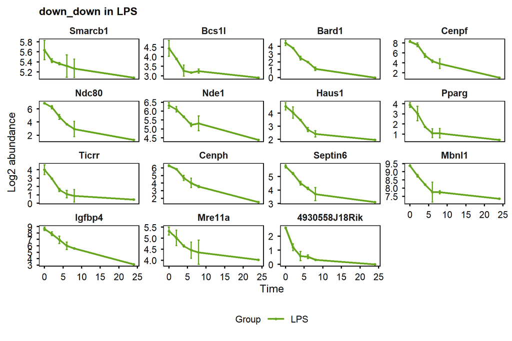

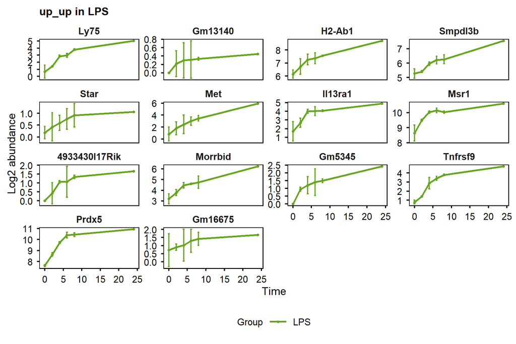

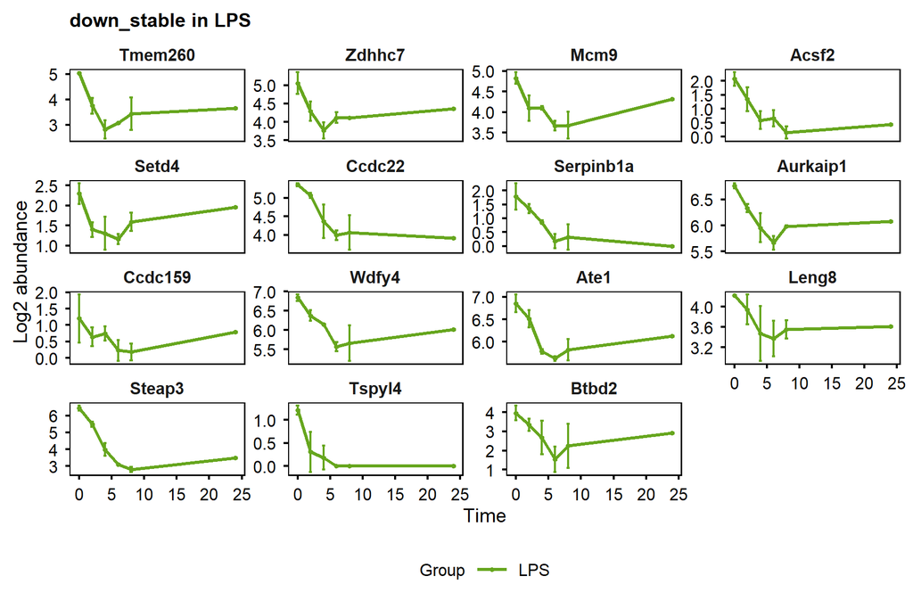

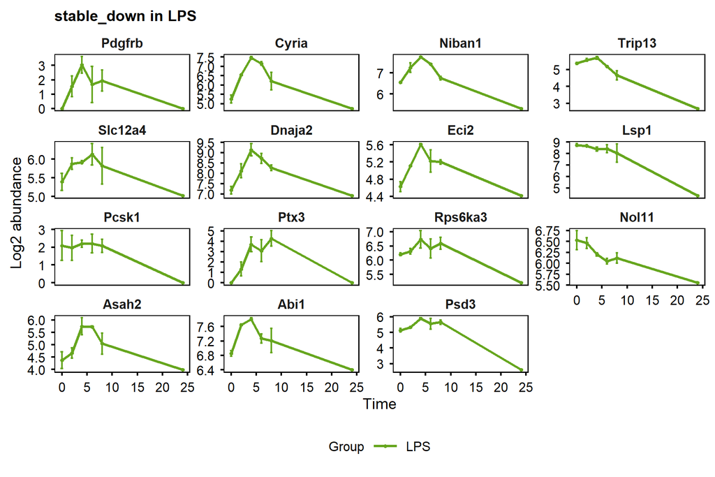

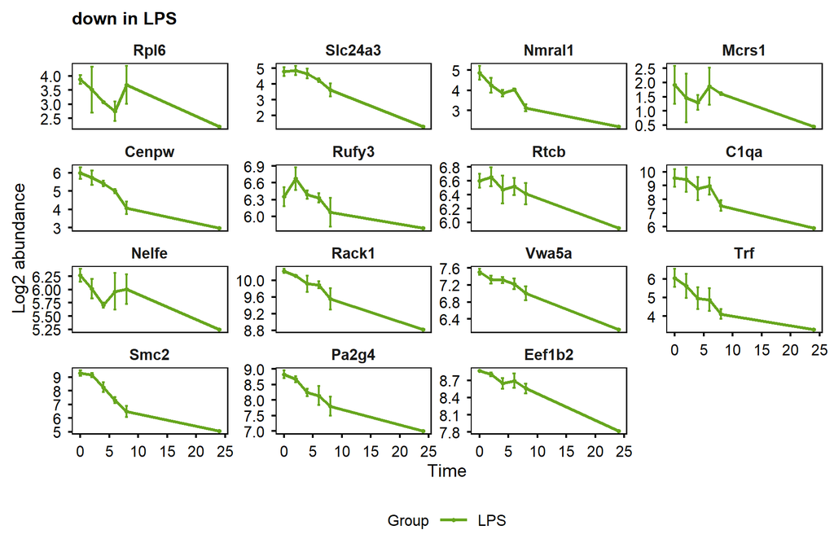

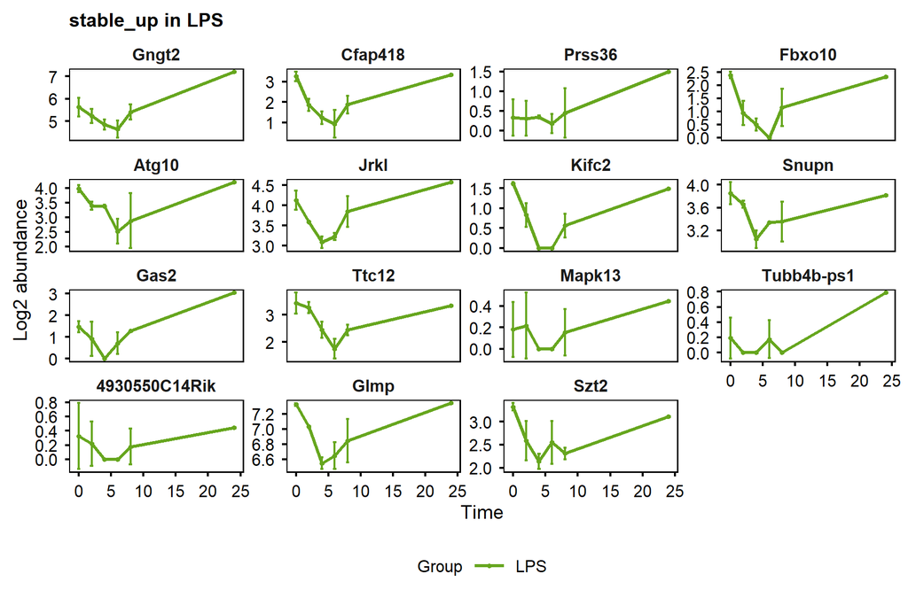

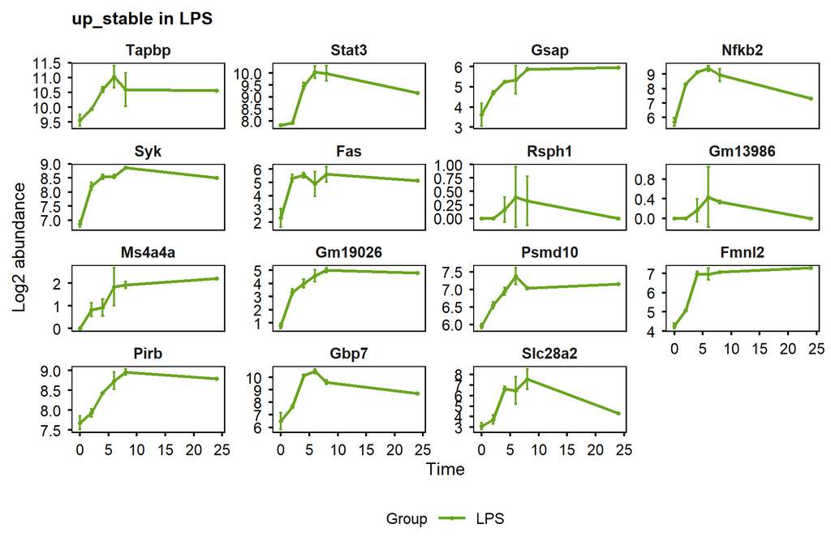

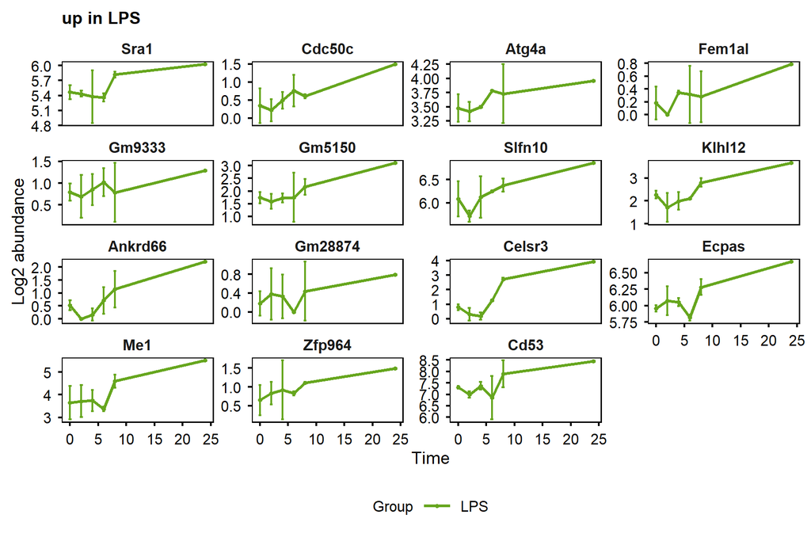

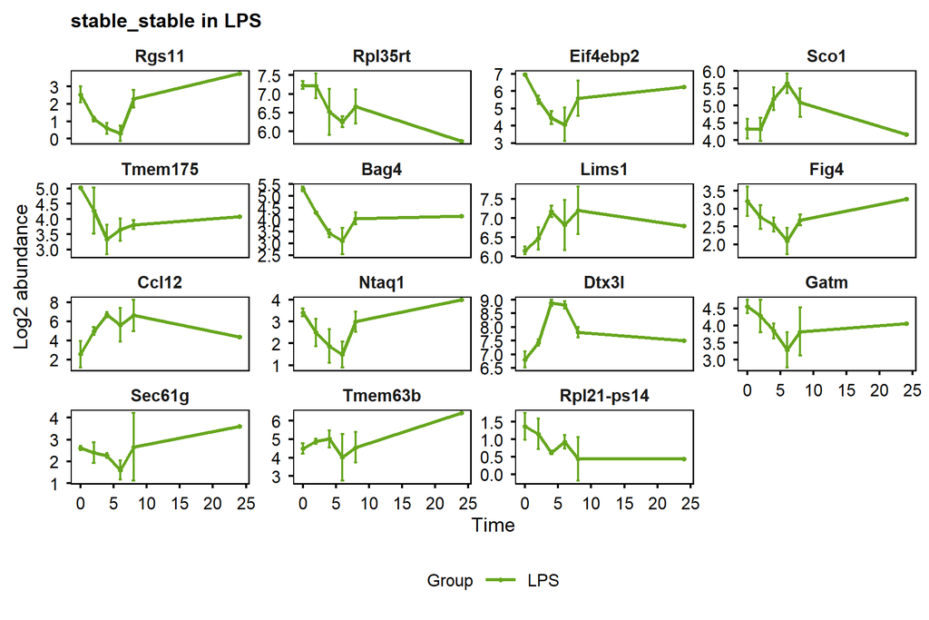

```r
# plot example genes with different trend patterns
i <- "LPS"
for (j in names(trendy_list[[i]])) {
    if (!is.null(trendy_list[[i]][[j]])) {
        print(plot_trend(table_mean_sd_orig,
            groups = i,
            features = trendy_list[[i]][[j]] |>
                sample(min(15, length(trendy_list[[i]][[j]]))),
            title = paste0(j)
        ))
    }
}
```

# 12 Variance decomposition analysis

## 12.1 Filter input

Input features are filtered to have at least 50% values > 0 in at least 2 groups, as comparison between groups is needed.

```r
filter_ratio <- 0.5
decomp_filter_genes <- group_specific_features(property_fc,
    filter_ratio = filter_ratio,
    group_pct = 2 / length(unique(data_obj$Group)),
    GO = FALSE, genename = FALSE
)$features
```

```
#> Filtering criteria: >=50% values >0 in >=2 of groups: Candida, IFNbeta, IFNgamma, LCMV, Listeria, LPS, untreated
```

## 12.2 Original data (not time 0 normalised) with replicates

Compared to normalised data, only using original data can identify genes with stable but different levels of expression in groups.

```r
var_decomp_1 <- decomp_variance(data_obj,
    features = decomp_filter_genes,
    interaction = TRUE,
    assay = 1, core = 16
)
```

```
#> Max 2 replicate(s): interaction variance estimate may be unstable.
#> LMM: exp ~ (1|Group) + (1|Time) + (1|Group:Time)  |  Output: Group, Time, Group:Time, Residual
#> 14546 features evaluated: 10352 successful; 0 errors; 4194 warnings; 0 skipped before fitting for insufficient observations or variance.
```

```
#> Features not specified. Plotting top 20 features ranked by Time.
```

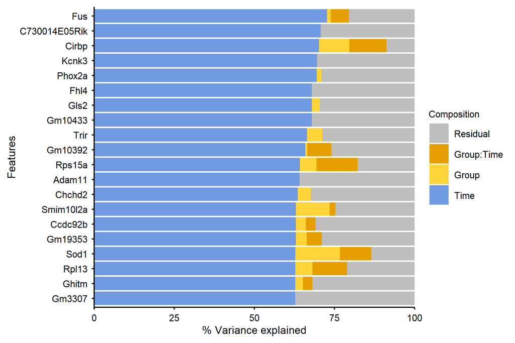

```r
plot_variance(var_decomp_1, rank = "Time", top_n = 20)
```

```
#> Features not specified. Plotting top 20 features ranked by Group.
```

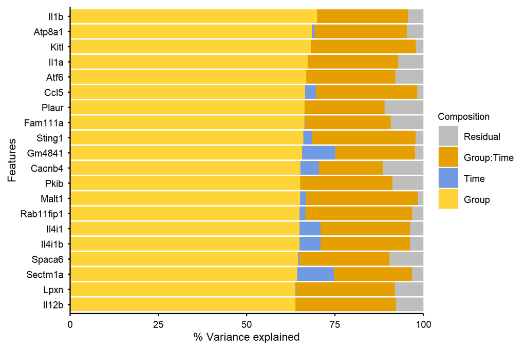

```r
plot_variance(var_decomp_1, rank = "Group", top_n = 20)
```

```
#> Specified top_n is larger than the number of features. Plotting all 14546 features.
```

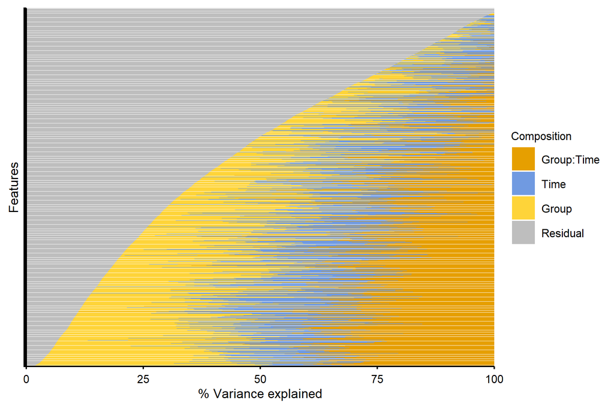

```r
plot_variance(var_decomp_1, rank = "Residual", top_n = Inf, show_ylab = FALSE)
```

```
#> Group not specified. Plotting all groups: Candida, IFNbeta, IFNgamma, LCMV, Listeria, LPS, untreated
```

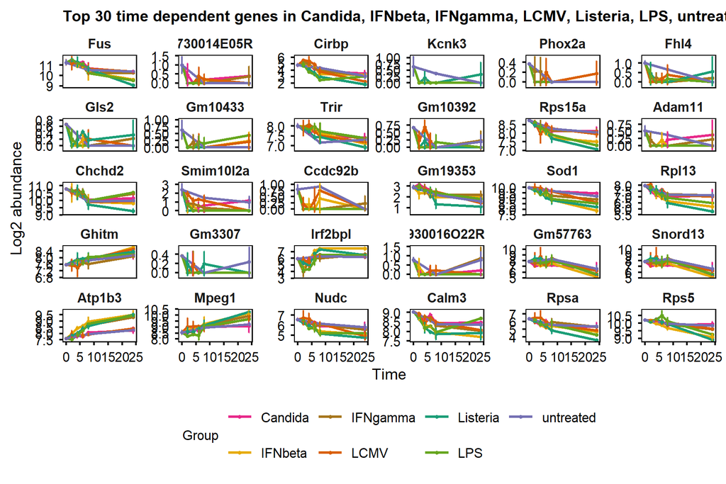

```r
plot_trend(table_mean_sd_orig,
    features = var_decomp_1 |> arrange(desc(Time)) |> head(30) |> pull(Feature),
    title = "Top 30 time dependent genes"
)
```

```
#> Group not specified. Plotting all groups: Candida, IFNbeta, IFNgamma, LCMV, Listeria, LPS, untreated
```

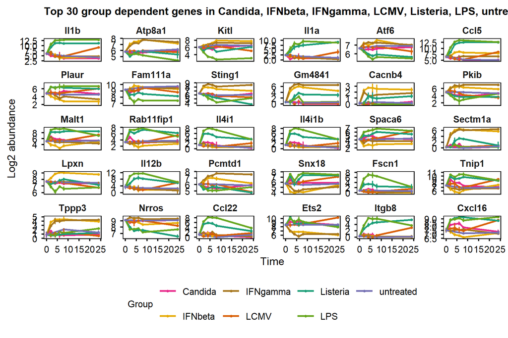

```r
plot_trend(table_mean_sd_orig,
    features = var_decomp_1 |> arrange(desc(Group)) |> head(30) |> pull(Feature),
    title = "Top 30 group dependent genes"
)
```

### 12.2.1 Residual variance quantified unexplained variation

```
#> Group not specified. Plotting all groups: Candida, IFNbeta, IFNgamma, LCMV, Listeria, LPS, untreated
```

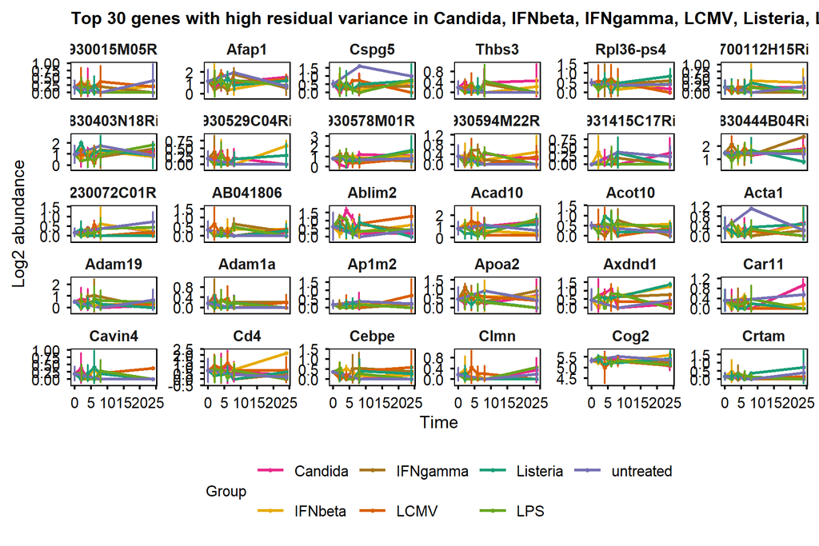

```r
plot_trend(table_mean_sd_orig,
    features = var_decomp_1 |> arrange(desc(Residual)) |> head(30) |> pull(Feature),
    title = "Top 30 genes with high residual variance"
)
```

```
#> Group not specified. Plotting all groups: Candida, IFNbeta, IFNgamma, LCMV, Listeria, LPS, untreated
```

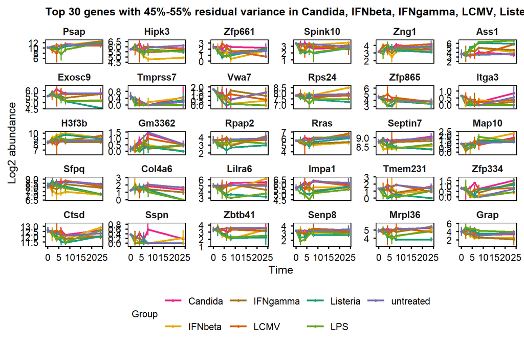

```r
plot_trend(table_mean_sd_orig,
    features = var_decomp_1 |> filter(Residual < 55 & Residual > 45) |>
        sample_n(30) |> pull(Feature),
    title = "Top 30 genes with 45%-55% residual variance"
)
```

```
#> Group not specified. Plotting all groups: Candida, IFNbeta, IFNgamma, LCMV, Listeria, LPS, untreated
```

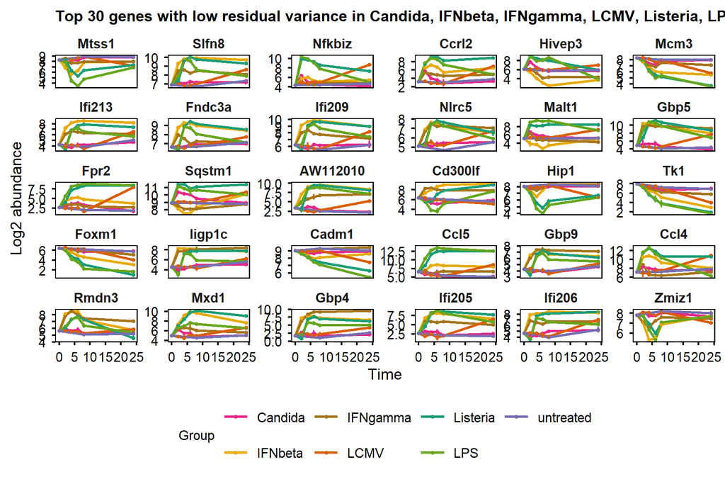

```r
plot_trend(table_mean_sd_orig,
    features = var_decomp_1 |> arrange(Residual) |> head(30) |> pull(Feature),
    title = "Top 30 genes with low residual variance"
)
```

```
#> Group not specified. Plotting all groups: Candida, IFNbeta, IFNgamma, LCMV, Listeria, LPS, untreated
```

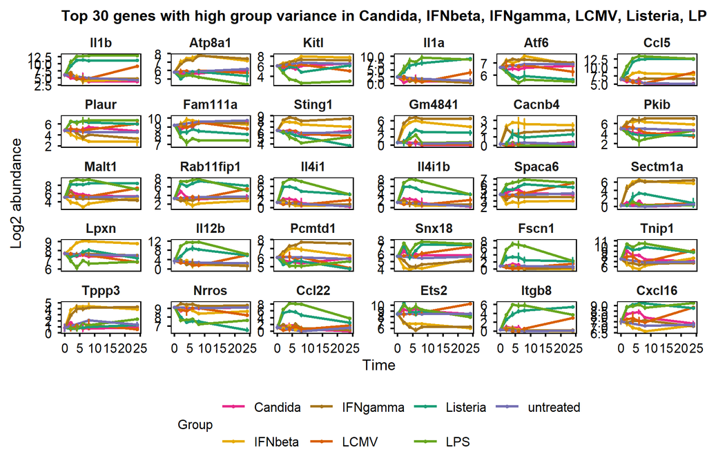

```r
plot_trend(table_mean_sd_orig,
    features = var_decomp_1 |> arrange(desc(Group)) |> head(30) |> pull(Feature),
    title = "Top 30 genes with high group variance"
)
```

```
#> Group not specified. Plotting all groups: Candida, IFNbeta, IFNgamma, LCMV, Listeria, LPS, untreated
```

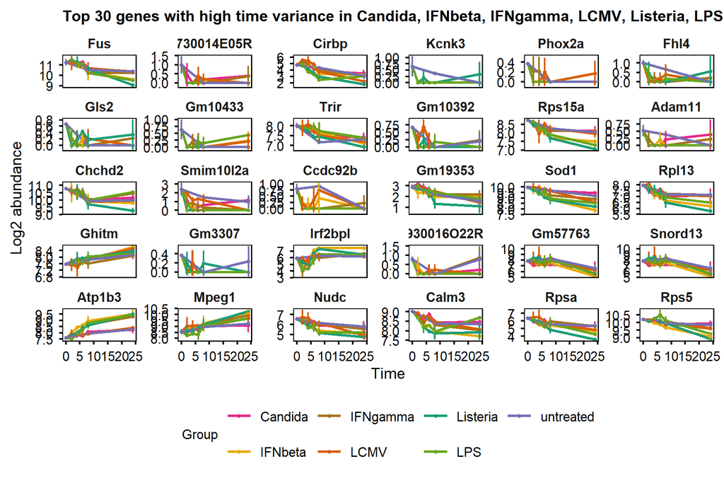

```r
plot_trend(table_mean_sd_orig,
    features = var_decomp_1 |> arrange(desc(Time)) |> head(30) |> pull(Feature),
    title = "Top 30 genes with high time variance"
)
```

```
#> Group not specified. Plotting all groups: Candida, IFNbeta, IFNgamma, LCMV, Listeria, LPS, untreated
```

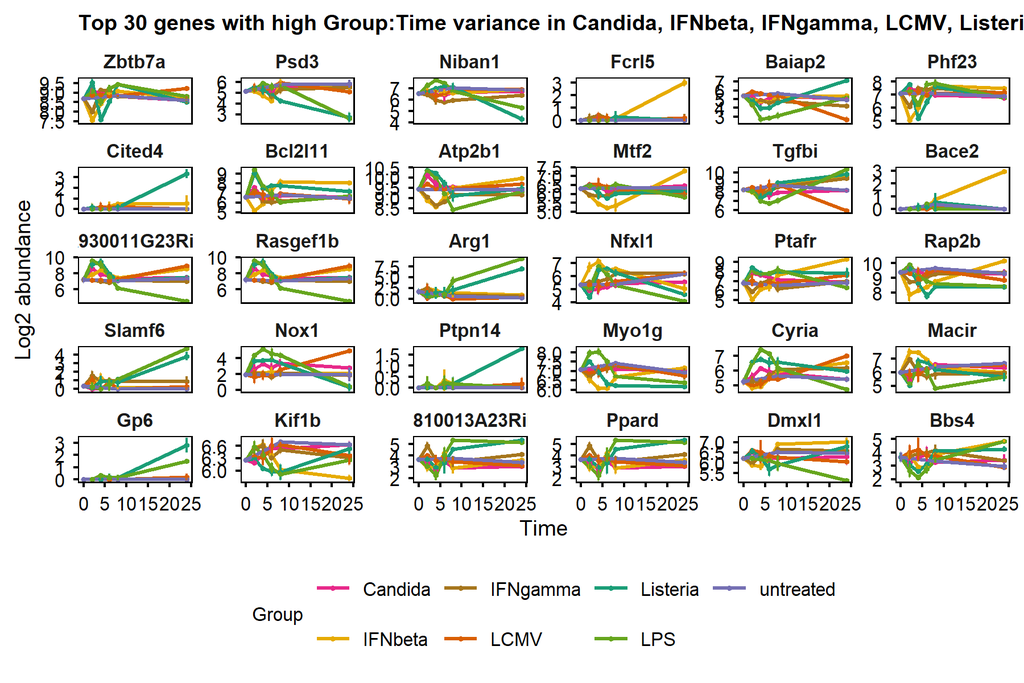

```r
plot_trend(table_mean_sd_orig,
    features = var_decomp_1 |> arrange(desc(`Group:Time`)) |> head(30) |> pull(Feature),
    title = "Top 30 genes with high Group:Time variance"
)
```

### 12.2.2 GO enrichment of genes ranked by group/time-contributed variance

`enrichGO_rank()` returns results under `$all` and `$simplified`, each containing a named list indexed by GO category (e.g. `$all$BP`, `$all$MF`, `$all$CC`). Specific category can be plotted by `enrichplot::gseaplot2()`.

```r
gse_group <- enrichGO_rank(var_decomp_1,
    gene_rank_by = "Group",
    OrgDb = org.Mm.eg.db,
    keyType = "SYMBOL", category = "BP",
    go_rank_by = "p.adjust")
```

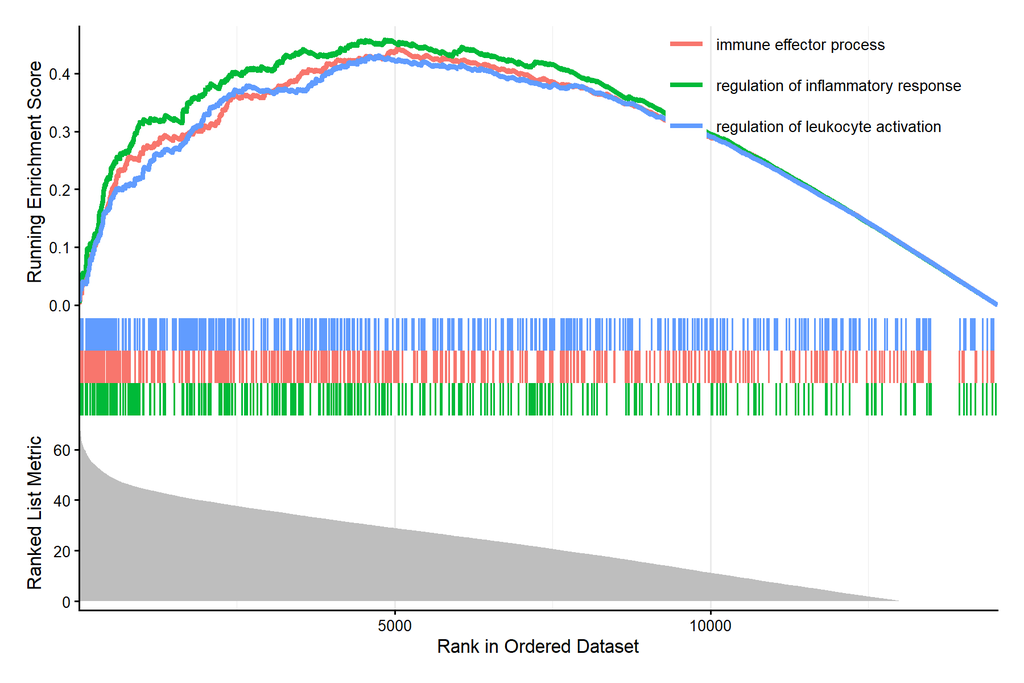

```r
enrichplot::gseaplot2(gse_group$all[["BP"]],
    geneSetID = 1:3, base_size = 8)
```

```r
gse_time <- enrichGO_rank(var_decomp_1,
    gene_rank_by = "Time",
    OrgDb = org.Mm.eg.db,
    keyType = "SYMBOL", category = "BP",
    go_rank_by = "p.adjust")
```

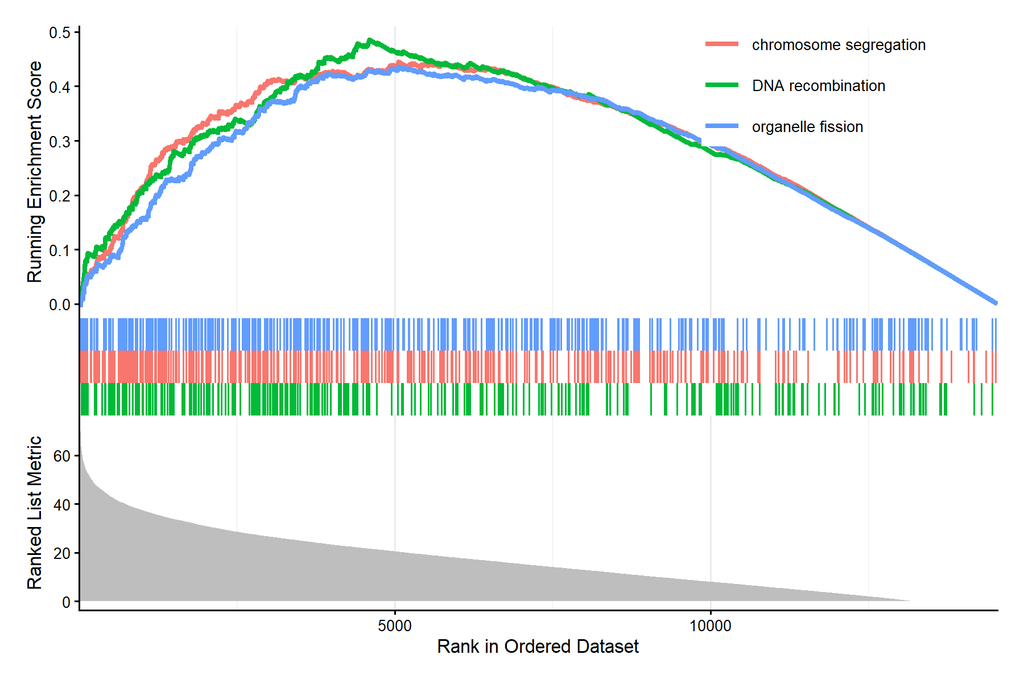

```r
enrichplot::gseaplot2(gse_time$all[["BP"]],
    geneSetID = 1:3, base_size = 8)
```

```r
gse_grouptime <- enrichGO_rank(var_decomp_1,
    gene_rank_by = "Group:Time",
    OrgDb = org.Mm.eg.db,
    keyType = "SYMBOL", category = "BP",
    go_rank_by = "p.adjust")
```

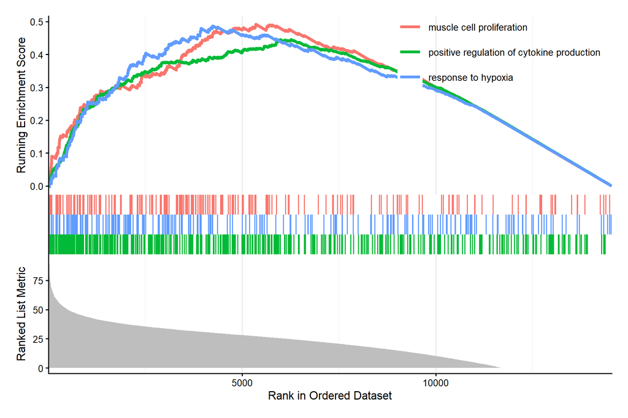

```r
enrichplot::gseaplot2(gse_grouptime$all[["BP"]],
    geneSetID = 1:3, base_size = 8)
```

## 12.3 Time 0 normalised data with replicates

In this dataset, all groups have the same starting status (untreated), so after normalisation to time 0, the variance decomposition is the same as the original data.

```r
var_decomp_1$Residual |> summary()
```

[output not shown]

# 13 Module identification with WGCNA

WGCNA reference: https://github.com/edo98811/WGCNA_official_documentation/

## 13.1 Filter input

exclude genes with high residual variance

```r
# time 0 normalised
gene_resid <- var_decomp_1 |>
    filter(Residual < var_res_q3_1) |>
    pull(Feature)
length(gene_resid) # only including genes with >=50% values >0 in >=2 groups
```

```
#> [1] 10909
```

use time 0 normalised data with replicates

```r
# filter_wgcna <- intersect(gene_resid, non_random_union)
#     # union(group_unique_genes)
# length(filter_wgcna)

data_obj_filtered <- data_obj[gene_resid, ]
dim(data_obj_filtered)
```

```
#> [1] 10909    76
```

## 13.2 Choose power

```r
wgcna_input <- prepare_WGCNA(data_obj_filtered,
    assay = 2,
    blockSize = 20000,
    powers = c(seq(1, 30, by = 1)),
    networkType = "signed",
    RsquaredCut = 0.8,
    MeanConnectivity = 100
)
```

```
#> Allowing multi-threading with up to 24 threads.
#>  pickSoftThreshold: calculating connectivity for given powers...
#>    ..working on genes 1 through 10909 of 10909
#>    Power SFT.R.sq  slope truncated.R.sq mean.k. median.k. max.k.
#> 1      1   0.7910  3.090         0.8410  6210.0   6590.00   7410
#> 2      2   0.2080  0.592         0.1760  3970.0   4290.00   5680
#> 3      3   0.0228 -0.162        -0.2530  2730.0   2920.00   4600
#> 4      4   0.2280 -0.480         0.0587  1970.0   2050.00   3830
#> 5      5   0.4100 -0.690         0.3930  1470.0   1470.00   3240
#> 6      6   0.5050 -0.815         0.5780  1120.0   1080.00   2780
#> 7      7   0.5540 -0.924         0.6750   877.0    797.00   2410
#> 8      8   0.5820 -1.020         0.7320   695.0    600.00   2110
#> 9      9   0.6000 -1.110         0.7610   559.0    455.00   1850
#> 10    10   0.6160 -1.200         0.7870   455.0    348.00   1640
#> 11    11   0.6280 -1.280         0.8030   374.0    268.00   1460
```

[output cut: 22 more lines]

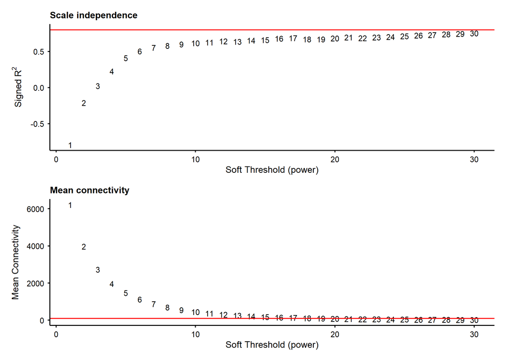

The R2 didn’t reach 0.8 under power 30, so use power 12 [as recommended](https://edo98811.github.io/WGCNA_official_documentation/faq.html) for signed networks.

## 13.3 Run WGCNA

```r
picked_power <- 12
minCoreKME <- 0.9
minKMEtoStay <- 0.7
reassignThreshold <- 0

net <- run_WGCNA(wgcna_input,
    power = picked_power,
    maxBlockSize = 20000,
    numericLabels = TRUE,
    minCoreKME = minCoreKME,
    minKMEtoStay = minKMEtoStay,
    reassignThreshold = reassignThreshold,
    verbose = 3
)
```

```
#> Allowing multi-threading with up to 24 threads.
#>  Calculating module eigengenes block-wise from all genes
#>    Flagging genes and samples with too many missing values...
#>     ..step 1
#>  ..Working on block 1 .
#>     TOM calculation: adjacency..
#>     ..will not use multithreading.
#>      Fraction of slow calculations: 0.000000
#>     ..connectivity..
#>     ..matrix multiplication (system BLAS)..
#>     ..normalization..
#>     ..done.
#>  ....clustering..
#>  ....detecting modules..
#>  ....calculating module eigengenes..
#>  ....checking kME in modules..
#>      ..removing 1733 genes from module 1 because their KME is too low.
#>      ..removing 392 genes from module 2 because their KME is too low.
#>      ..removing 235 genes from module 3 because their KME is too low.
#>      ..removing 445 genes from module 4 because their KME is too low.
#>      ..removing 88 genes from module 5 because their KME is too low.
#>      ..removing 113 genes from module 6 because their KME is too low.
#>      ..removing 120 genes from module 7 because their KME is too low.
#>      ..removing 207 genes from module 8 because their KME is too low.
#>      ..removing 149 genes from module 9 because their KME is too low.
#>      ..removing 119 genes from module 10 because their KME is too low.
#>      ..removing 78 genes from module 11 because their KME is too low.
#>      ..removing 83 genes from module 13 because their KME is too low.
#>      ..removing 47 genes from module 15 because their KME is too low.
#>      ..removing 30 genes from module 17 because their KME is too low.
#>      ..removing 3 genes from module 19 because their KME is too low.
#>      ..removing 4 genes from module 22 because their KME is too low.
#>  ..merging modules that are too close..
#>      mergeCloseModules: Merging modules whose distance is less than 0.15
#>        Calculating new MEs...
```

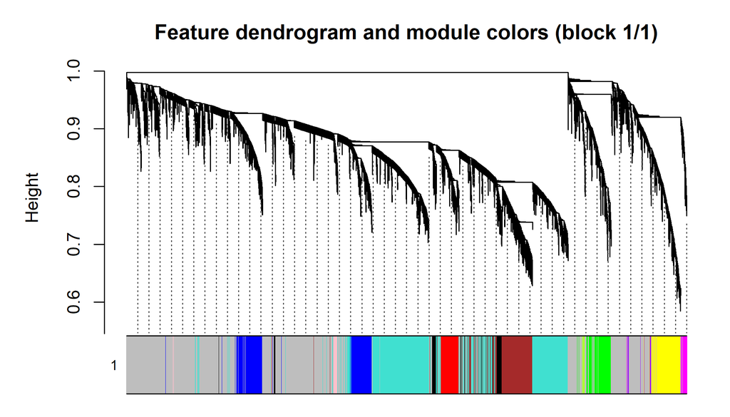

[output not shown]

[output cut: 22 more lines]

[output not shown]

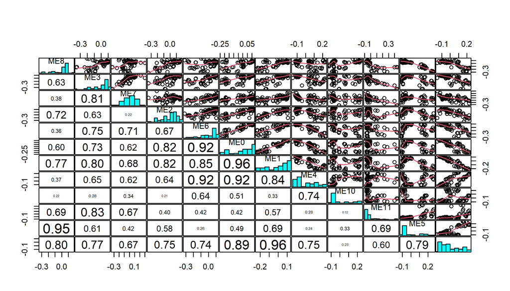

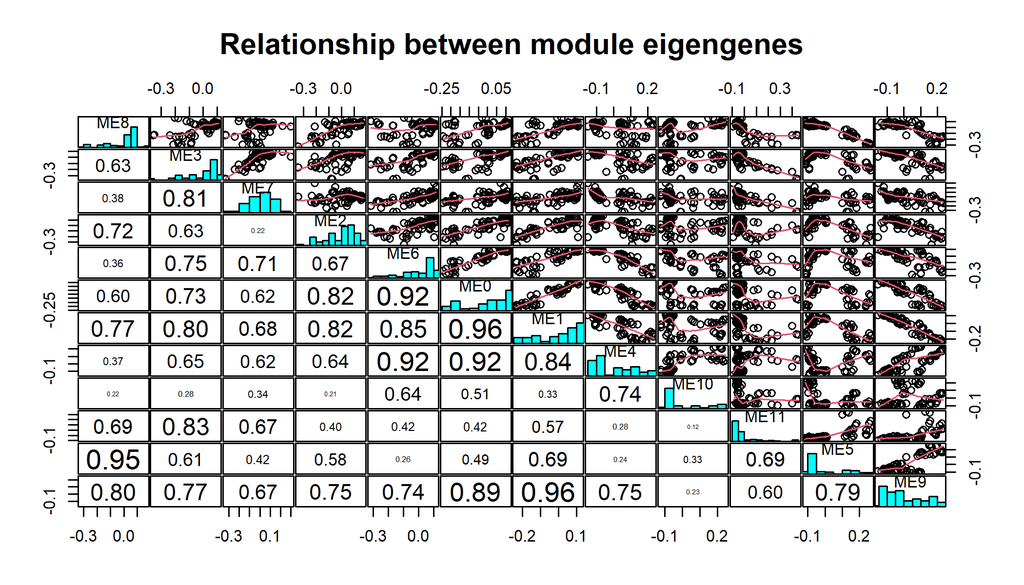

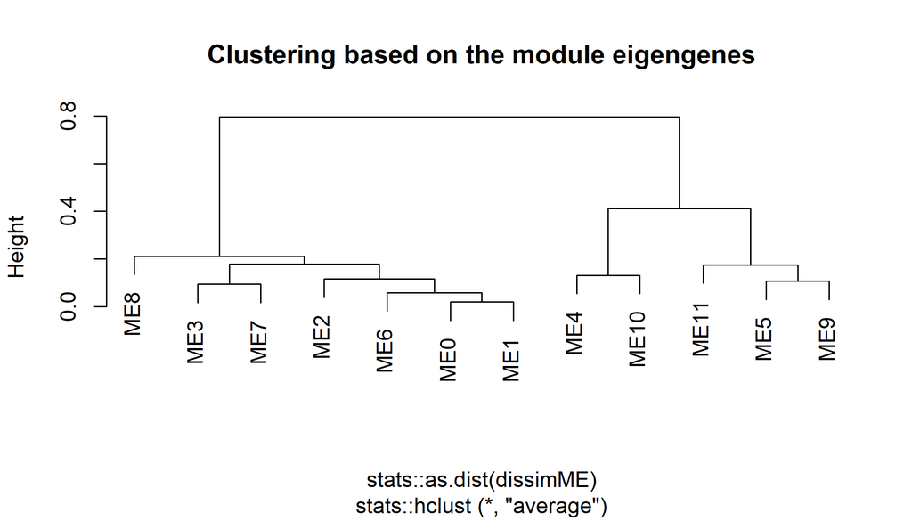

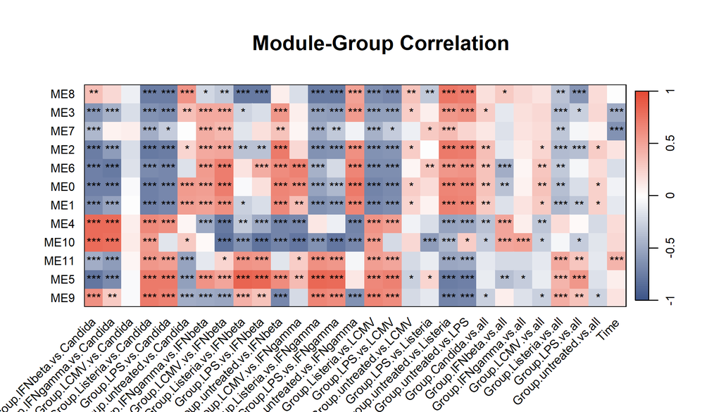

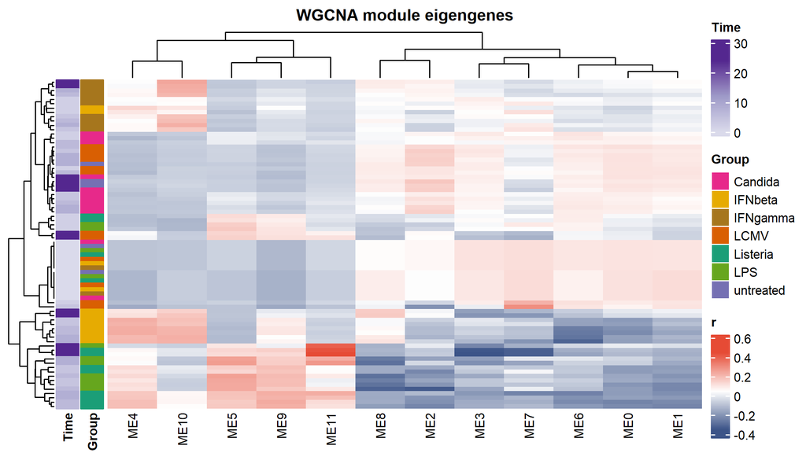

```r
plot_WGCNA(net = net)
```

`WGCNA_module()` converts the WGCNA network output to a standardised two-column data.frame (`Feature`, `Module`), accepted by all downstream plotting and enrichment functions. It optionally excludes the grey (unassigned) module.

```r
gene_module <- WGCNA_module(net)

gene_module |>
    dplyr::group_by(Module) |>
    dplyr::summarise(n = n())
```

| Module | n |
| --- | --- |
| 0 | 4784 |
| 1 | 2464 |
| 2 | 976 |
| 3 | 825 |
| 4 | 537 |
| 5 | 396 |
| 6 | 361 |
| 7 | 235 |
| 8 | 97 |
| 9 | 97 |

[output cut: 2 more lines]

```r
n_module <- length(unique(gene_module$Module)) - 1  # excluding grey (0)
```

## 13.4 Module quality

`summarise_module_metrics()` computes per-module statistics from the WGCNA network: module size, proportion of features assigned, and module membership (kME) statistics. `MeanKME` is the mean module membership (kME = cor(feature, module eigengene)); `MeanKME2` = mean(kME^2) is the average proportion of per-feature variance explained by the module eigengene.

```r
summarise_module_metrics(net) |>
    dplyr::arrange(dplyr::desc(Size))
```

| Module | Size | Proportion | MeanKME | MeanKME2 | MedianKME | SDKME | Q25KME | Q75KME | MinKME | MaxKME |
| --- | --- | --- | --- | --- | --- | --- | --- | --- | --- | --- |
| M1 | 2464 | 0.225868549 | 0.8099080 | 0.6621067 | 0.8135280 | 0.07847367 | 0.7507534 | 0.8723185 | 0.4925070 | 0.9733198 |
| M2 | 976 | 0.089467412 | 0.7912217 | 0.6328852 | 0.8023788 | 0.08282719 | 0.7410415 | 0.8521074 | 0.4229151 | 0.9556912 |
| M3 | 825 | 0.075625630 | 0.8624811 | 0.7488236 | 0.8734846 | 0.07039850 | 0.8164770 | 0.9179574 | 0.6980852 | 0.9810242 |
| M4 | 537 | 0.049225410 | 0.8362022 | 0.7050551 | 0.8323721 | 0.07636590 | 0.7700115 | 0.9041433 | 0.6806784 | 0.9790626 |
| M5 | 396 | 0.036300303 | 0.8015076 | 0.6502407 | 0.8095595 | 0.08857751 | 0.7341763 | 0.8743159 | 0.5593476 | 0.9695631 |
| M6 | 361 | 0.033091942 | 0.8609799 | 0.7440984 | 0.8660159 | 0.05310235 | 0.8323146 | 0.8987670 | 0.6795811 | 0.9639549 |
| M7 | 235 | 0.021541846 | 0.8539427 | 0.7345749 | 0.8723496 | 0.07334587 | 0.8151296 | 0.9090825 | 0.5622894 | 0.9766235 |
| M8 | 97 | 0.008891741 | 0.8382977 | 0.7070731 | 0.8455651 | 0.06614430 | 0.8172434 | 0.8786265 | 0.6463971 | 0.9653786 |
| M9 | 97 | 0.008891741 | 0.8209046 | 0.6794915 | 0.8063785 | 0.07526975 | 0.7635326 | 0.8896574 | 0.6932296 | 0.9601023 |
| M10 | 80 | 0.007333394 | 0.8163447 | 0.6711098 | 0.8239031 | 0.06892365 | 0.7553351 | 0.8669465 | 0.6801507 | 0.9706718 |

[output cut: 1 more lines]